### 6.4 The nitty gritty of matplotlylib

Out of curiosity or for the sake of troubleshooting, you might find yourself needing to inspect the dictionaries and possibly even the mplexporter. The following shows how you go about running the PlotlyRenderer and making a manual call to Plotly.

We start with the simplest of matplotlib plots:

```
(90, 310)
```

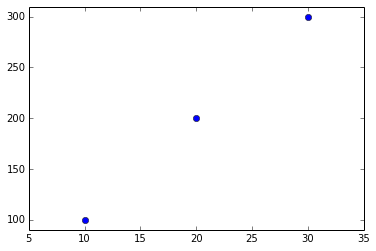

```python
mpl_fig_ng = plt.figure()         # set new mpl figure obj.
ax = mpl_fig_ng.add_subplot(111)  # add axis

ax.plot([10, 20, 30], [100, 200, 300], 'bo')  # add a few pts too plot

ax.set_xlim(5, 35)    # set axes limits
ax.set_ylim(90, 310)
```

First, we will need access to the Exporter and PlotlyRenderer classes:

```python
from plotly.matplotlylib import Exporter, PlotlyRenderer

renderer = PlotlyRenderer()    # make shorcuts
exporter = Exporter(renderer)
```

The Exporter crawls through the matplotlib figure, judiciously grabs pertinent information, and invokes the renderer with which it was instantiated. The PlotlyRenderer accepts calls from the Exporter and creates an appropriate JSON dictionary for use with Plotly. So,

```python
# Grab info from matplotlib figure
exporter.run(mpl_fig_ng)
```

```python
# Create JSON dictionary for use with Plotly
renderer.plotly_fig
```

```
{'data': [{'marker': {'color': '#0000FF',
    'line': {'color': '#000000', 'width': 0.5},
    'opacity': 1,
    'size': 6,
    'symbol': 'dot'},
   'mode': 'markers',
   'name': '_line0',
   'type': u'scatter',
   'x': [10.0, 20.0, 30.0],
   'xaxis': 'x1',
   'y': [100.0, 200.0, 300.0],
   'yaxis': 'y1'}],
 'layout': {'autosize': False,
  'height': 320,
  'hovermode': 'closest',
  'margin': {'b': 40, 'l': 60, 'pad': 0, 'r': 47, 't': 31},
  'showlegend': False,
  'width': 480,
  'xaxis1': {'anchor': 'y1',
   'domain': [0.0, 1.0],
   'mirror': 'ticks',
   'nticks': 7,
   'range': [5.0, 35.0],
   'showgrid': False,
   'showline': True,
   'side': 'bottom',
   'tickfont': {'size': 10.0},
   'ticks': 'inside',
   'type': 'linear',
   'zeroline': False},
  'yaxis1': {'anchor': 'x1',
   'domain': [0.0, 1.0],
   'mirror': 'ticks',
   'nticks': 7,
   'range': [90.0, 310.0],
   'showgrid': False,
   'showline': True,
   'side': 'left',
   'tickfont': {'size': 10.0},
   'ticks': 'inside',
   'type': 'linear',
   'zeroline': False}}}
```

OK.

Finally, to create the figure in Plotly, call `py.iplot` :

```python
py.iplot(renderer.plotly_fig, filename='s6_nitty-gritty')
```

[interactive chart not shown]

Additionally, you can use this opportunity to add to or modify the data and layout dictionaries. Just as an example, we can change the plot and paper background colors:

```python
# Use Plotly's default auto-size
renderer.resize()

# Add a few layout features to the figure object
renderer.plotly_fig['layout']['plot_bgcolor'] = '#80adb0'
renderer.plotly_fig['layout']['paper_bgcolor'] = '#fefafd'

# Send updated figur object
py.iplot(renderer.plotly_fig, filename='s6_nitty-gritty2')
```

[interactive chart not shown]

#### Go to Section 7 --- Plotly's Streaming API

#### Go to Section 5 --- Heatmaps, Contours and 2D Histograms

#### Go to User Guide's homepage

[figure not shown]

#### Got Questions or Feedback?

About [Plotly](https://plot.ly)

- email: feedback@plot.ly
- tweet: [@plotlygraphs](https://twitter.com/plotlygraphs)

About the [User Guide](https://github.com/plotly/python-user-guide)

- email: etienne@plot.ly
- tweet: [@etpinard](https://twitter.com/etpinard)

#### Notebook styling ideas

Big thanks to

- [Cam Davidson-Pilon](http://nbviewer.ipython.org/github/CamDavidsonPilon/Probabilistic-Programming-and-Bayesian-Methods-for-Hackers/blob/master/Prologue/Prologue.ipynb)
- [Lorena A. Barba](http://lorenabarba.com/blog/announcing-aeropython/#.U1ULXdX1LJ4.google_plusone_share)